# Lab 12: Web Scraping

Sandeep Tiwari

12/2/2017

### Learning Objectives

> - Work with the package `"rvest"`
> - Learn to extract html elements and attributes
> - Create a simple crawler

## Required Packages

In this lab, you will have to load the following R packages:

```r
library(XML)
library(xml2)
library(rvest)
library(magrittr)
```

## Motivation

The goal of this lab is to extract the Roster Tables of all the NBA teams from the website https://www.basketball-reference.com/

More specifically, you will extract the rosters of the season 2016-2017. One example of such table is displayed in the image below with the Roster of Golden State Warriors (GSW):

[figure not shown]

The GSW Roster table is in the URL:

https://www.basketball-reference.com/teams/GSW/2017.html

You can read this table in R via the `"XML"` function `readHTMLTable()`:

```r
# Assemble url (so it fits on screen)
basket <- "https://www.basketball-reference.com"
gsw <- "/teams/GSW/2017.html"
gsw_url <- paste0(basket, gsw)

# download HTML file to your working directory
download.file(gsw_url, 'gsw-roster-2017.html')

# Read GSW Roster html table
gsw_roster <- readHTMLTable('gsw-roster-2017.html')
```

### Roster tables

Say you are interested in obtaining the Roster table for the Boston Celtics (BOS). You could get such table by adapting the code used to get the GSW roster. The only thing you need to change is the team abbreviation from `GSW` to `BOS`:

```r
# Assemble url (so it fits on screen)
basket <- "https://www.basketball-reference.com"
bos <- "/teams/BOS/2017.html"
bos_url <- paste0(basket, bos)

# download HTML file to your working directory
download.file(bos_url, 'bos-roster-2017.html')

# Read BOS Roster html table
bos_roster <- readHTMLTable('bos-roster-2017.html')
```

In order to get the Roster tables of all the NBA teams, you would need to repeat the same operation with the corresponding team abbreviations. But how do you get these abbreviations in a programmatic way?

## 2016-17 NBA Season Summary

To get the team abbreviations in a programmatic way, you need to find URLs of the form `"/teams/GSW/2017.html"`, `"/teams/BOS/2017.html"`, etc. These pieces of information are available in the Basketball-Reference website in several web pages.

In particular, this page contains information about the *Conference Standings* displayed in two HTML tables (see screenshot below)

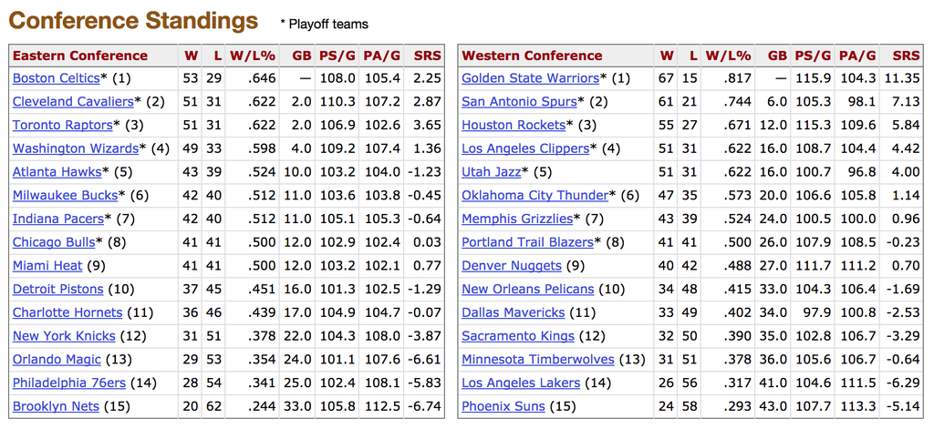

We don’t really care about the conference standings. What we care about is that these two HTML tables contain both: the names of the NBA teams (rendered on your browser), as well as the href attributes of the form: `"/teams/GSW/2017.html"`.

If you use Google Chrome as your web browser, you can inspect the HTML source code by right clicking on your mouse, and selecting the `Inspect` option. For instance, place the cursor over the *Boston Celtics* link, and then launch the inspector:

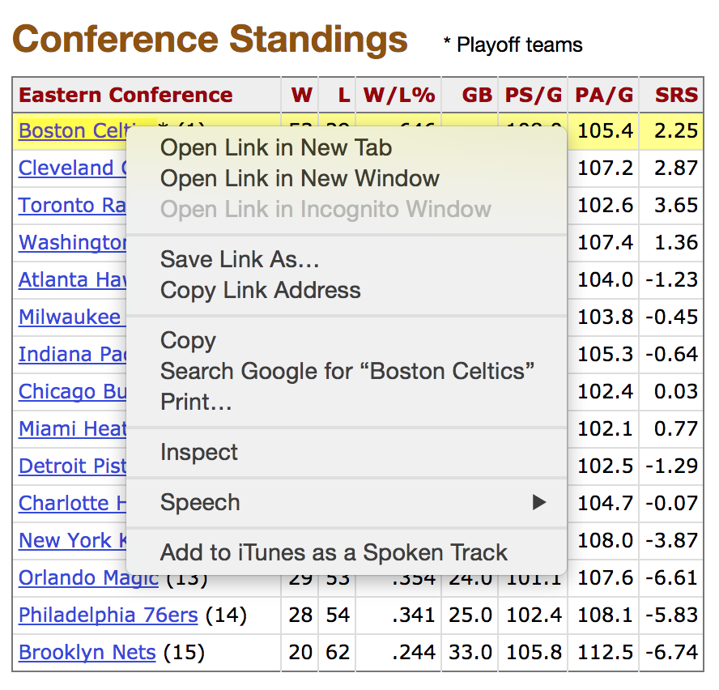

If you look at the HTML source, you will see the `href` attributes for each team page. In other words, these are the links to each team’s web page. And this is exactly the piece of information we are looking for: the team abbreviations.

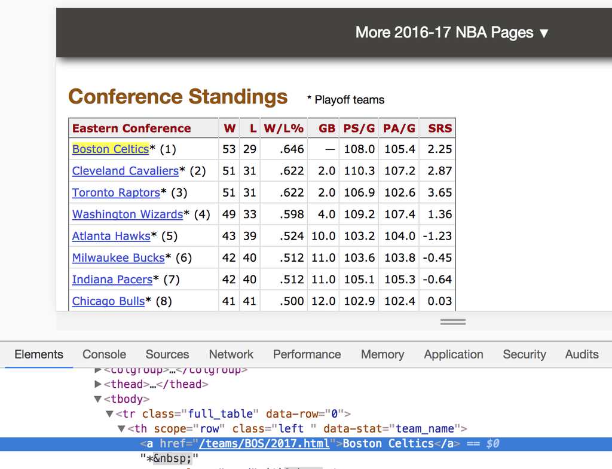

## Extracting HTML elements

So how do we extract these `href` attributes? The first step is to read the contents of the html file:

This can be done with the function `read_html()`

```r
nba_html <- paste0(basket, "/leagues/NBA_2017.html")

xml_doc <- read_html(nba_html)
```

The object `xml_doc` is an object of class `"xml_document"`. If you are curious about extracting all the content in a character vector, then use the function `html_text()`, chained with the pipe `%>%` operator:

```r
xml_text <- xml_doc %>% html_text()
```

The object `xml_text` is a character vector that contains the content of the html file.

### Extracting elements `h2`

Before attempting extracting the href attributes, let’s begin with something simpler. For example, let’s see how to extract the value of all the HTML elements **h2** (i.e. headings of level 2). This can be done with the function `html_nodes()`, and then `html_text()`

```r
# content of h2 nodes
xml_doc %>%
  html_nodes("h2") %>%
  html_text()
```

```
##  [1] "Conference Standings"         " "
##  [3] "Division Standings"           " "
##  [5] "Playoff Series"               "Team Per Game Stats"
##  [7] "Opponent Per Game Stats"      "Team Stats"
##  [9] "Opponent Stats"               "Team Per 100 Poss Stats"
## [11] "Opponent Per 100 Poss Stats"  "Miscellaneous Stats"
## [13] "Team Shooting"                "Opponent Shooting"
## [15] "League Awards"                "Players of the Week & Month"
## [17] "League Leaders"               "All-NBA"
## [19] "All-Defensive"                "All-Rookie"
## [21] "All-Star Game Rosters"        "More 2016-17 NBA Pages"
## [23] "Full Site Menu"               "We're Social...for Statheads"
## [25] "FAQs, Tip & Tricks"
```

You can pass the name of an HTML element (i.e. a tag or node) to `html_nodes()`. In this case, we indicate that we want to locate the nodes `"h2"`. And then we call `html_text()` to *extract* the actual content in those nodes.

### Your turn

Use `html_nodes()` and `html_text()` to extract the values of nodes:

- `"h1"`
- `"strong"`
- `"button"`

```r
xml_doc %>%
  html_nodes("h1") %>%
  html_text
```

```
## [1] "\n\t\t\t\t\n\t\t\t\t2016-17 NBA Season Summary\n\t\t\t\t\n\t\t\t"
```

```r
xml_doc %>%
  html_nodes("strong") %>%
  html_text
```

```
##  [1] "Season Summary"       "League Champion"      "Most Valuable Player"
##  [4] "Rookie of the Year"   "PPG Leader"           "RPG Leader"
##  [7] "APG Leader"           "WS Leader"            "Player Stats"
## [10] "Other"                "Atlantic Division"    "Central Division"
## [13] "Southeast Division"   "Northwest Division"   "Pacific Division"
## [16] "Southwest Division"   "Player Stats"         "Other"
## [19] "Season Summary"       "In the News"          "All-Time Greats"
## [22] "Active Greats"        "Atlantic"             "Central"
## [25] "Southeast"            "Northwest"            "Pacific"
## [28] "Southwest"            "Player Finders"       "Team Finders"
## [31] "Other Finders"        "Site Last Updated:"
```

```r
xml_doc %>%
  html_nodes("button") %>%
  html_text
```

```
## [1] "More league info"       "More 2016-17 NBA Pages"
```

What if you want to extract HTML tags or nodes that have an attribute? For instance, if you look at the source code, starting at line 356 you will see the following HTML elements for *Player Stats*:

```html
<p class="listhead"><strong>Player Stats</strong></p>
    <ul class="">
        <li><a href="/leagues/NBA_2017_per_game.html">Per Game</a></li>
        <li><a href="/leagues/NBA_2017_totals.html">Totals</a></li>
        <li><a href="/leagues/NBA_2017_per_minute.html">Per 36 Minutes</a></li>
        <li><a href="/leagues/NBA_2017_per_poss.html">Per 100 Possessions</a></li>
        <li><a href="/leagues/NBA_2017_advanced.html">Advanced</a></li>
    </ul>
```

As you can tell, there is a `p` element (i.e. html paragraph) of class `"listhead"`. You can actually specify this type of node with the name of the html element, followed by a dot, followed by the name of the attribute:

```r
# node with an attribute
xml_doc %>%
  html_nodes("p.listhead") %>%
  html_text()
```

```
## [1] "Player Stats"          "Other"                 "2017 Playoffs Summary"
## [4] "Player Stats"          "Other"                 "2017 Playoffs Summary"
```

## XPath

In order to specify HTML elements that are embeded inside other HTML elements, you need to use **XPaths**.

XPath expressions have a syntax similar to the way files are located in a hierarchy of directories/folders in a computer file system. To be more precise, Xpath expressions allow you to indicate the specific *path* that must be taken to arrive at a given node.

In general, we can specify paths through the tree structure:

- based on node names
- based on node content
- based on a node’s relationship to other nodes

| Symbol | Description |
| --- | --- |
| `/` | selects from the root node |
| `//` | selects nodes anywhere |
| `.` | selects the current node |
| `..` | Selects the parent of the current node |
| `@` | Selects attributes |
| `[]` | Square brackets to indicate attributes |

Let’s go back to the `p.listhead` nodes. These can be extracted with an Xpath expression like this:

```r
xml_doc %>%
  html_nodes(xpath = '//p[@class="listhead"]') %>%
  html_text()
```

```
## [1] "Player Stats"          "Other"                 "2017 Playoffs Summary"
## [4] "Player Stats"          "Other"                 "2017 Playoffs Summary"
```

The XPath `'//p[@class="listhead"]'` means that we want to locate, anywhere in the tree (`//`), all `<p>` nodes that have an attribute named `class` that takes the value `"listhead"`.

What if you want to extract the `<a>` values inside the listed items `<li>`, within the unlisted list `<ul>`?

```r
xml_doc %>%
  html_nodes(xpath = '//ul[@class=""]/li/a') %>%
  html_text()
```

```
##  [1] "Per Game"             "Totals"               "Per 36 Minutes"
##  [4] "Per 100 Possessions"  "Advanced"             "Debuts"
##  [7] "Final Season"         "Team Ratings"         "Uniform Numbers"
## [10] "Transactions"         "Standings"            "Schedule and Results"
## [13] "Leaders"              "Per Game"             "Totals"
## [16] "Per 36 Minutes"       "Per 100 Possessions"  "Advanced"
## [19] "Debuts"               "Final Season"         "Team Ratings"
## [22] "Uniform Numbers"      "Transactions"         "Standings"
## [25] "Schedule and Results" "Leaders"              "Per Game"
## [28] "Totals"               "Per 36 Minutes"       "Per 100 Possessions"
## [31] "Advanced"             "Debuts"               "Final Season"
## [34] "Team Ratings"         "Uniform Numbers"      "Transactions"
```

or equivalently:

```r
xml_doc %>%
  html_nodes(xpath = '//ul[@class=""]//a') %>%
  html_text()
```

```
##  [1] "Per Game"             "Totals"               "Per 36 Minutes"
##  [4] "Per 100 Possessions"  "Advanced"             "Debuts"
##  [7] "Final Season"         "Team Ratings"         "Uniform Numbers"
## [10] "Transactions"         "Standings"            "Schedule and Results"
## [13] "Leaders"              "Per Game"             "Totals"
## [16] "Per 36 Minutes"       "Per 100 Possessions"  "Advanced"
## [19] "Debuts"               "Final Season"         "Team Ratings"
## [22] "Uniform Numbers"      "Transactions"         "Standings"
## [25] "Schedule and Results" "Leaders"              "Per Game"
## [28] "Totals"               "Per 36 Minutes"       "Per 100 Possessions"
## [31] "Advanced"             "Debuts"               "Final Season"
## [34] "Team Ratings"         "Uniform Numbers"      "Transactions"
```

## Extracting `href` attributes

Let’s focus again on the first two html tables of the page https://www.basketball-reference.com/leagues/NBA_2017.html.

To extract the first `"table"` you can use `html_nodes()` and `extract()` as follows:

```r
# extracting first table
xml_table1 <- xml_doc %>%
  html_nodes("table") %>%
  extract(1)

class(xml_table1)
```

```
## [1] "xml_nodeset"
```

The object `xml_table1` is not really an R table, but an object of class `xml_nodeset`. To extract the html table as a data frame, `"rvest"` provides the function `html_table()`:

```r
tbl1 <- html_table(xml_table1)

head(tbl1)
```

```
## [[1]]
##          Eastern Conference  W  L  W/L%   GB  PS/G  PA/G   SRS
## 1       Boston Celtics* (1) 53 29 0.646    — 108.0 105.4  2.25
## 2  Cleveland Cavaliers* (2) 51 31 0.622  2.0 110.3 107.2  2.87
## 3      Toronto Raptors* (3) 51 31 0.622  2.0 106.9 102.6  3.65
## 4   Washington Wizards* (4) 49 33 0.598  4.0 109.2 107.4  1.36
## 5        Atlanta Hawks* (5) 43 39 0.524 10.0 103.2 104.0 -1.23
## 6      Milwaukee Bucks* (6) 42 40 0.512 11.0 103.6 103.8 -0.45
## 7       Indiana Pacers* (7) 42 40 0.512 11.0 105.1 105.3 -0.64
## 8        Chicago Bulls* (8) 41 41 0.500 12.0 102.9 102.4  0.03
## 9            Miami Heat (9) 41 41 0.500 12.0 103.2 102.1  0.77
## 10     Detroit Pistons (10) 37 45 0.451 16.0 101.3 102.5 -1.29
## 11   Charlotte Hornets (11) 36 46 0.439 17.0 104.9 104.7 -0.07
## 12     New York Knicks (12) 31 51 0.378 22.0 104.3 108.0 -3.87
## 13       Orlando Magic (13) 29 53 0.354 24.0 101.1 107.6 -6.61
## 14  Philadelphia 76ers (14) 28 54 0.341 25.0 102.4 108.1 -5.83
## 15       Brooklyn Nets (15) 20 62 0.244 33.0 105.8 112.5 -6.74
```

Likewise, the second html table can be extracted (as an `xml_nodeset`) in the following way:

```r
# extracting second table
xml_table2 <- xml_doc %>%
  html_nodes("table") %>%
  extract(2)
```

Actually, both tables can be extracted simultaneously:

```r
# two html tables
xml_tables <- xml_doc %>%
  html_nodes("table") %>%
  extract(1:2)
```

Having extracted the tables we are interested in, we can select the `<a>` nodes, and then extract the content that corresponds to the name of the teams:

```r
# extract names of teams
xml_tables %>%
  html_nodes("a") %>%
  html_text()
```

```
##  [1] "Boston Celtics"         "Cleveland Cavaliers"
##  [3] "Toronto Raptors"        "Washington Wizards"
##  [5] "Atlanta Hawks"          "Milwaukee Bucks"
##  [7] "Indiana Pacers"         "Chicago Bulls"
##  [9] "Miami Heat"             "Detroit Pistons"
## [11] "Charlotte Hornets"      "New York Knicks"
## [13] "Orlando Magic"          "Philadelphia 76ers"
## [15] "Brooklyn Nets"          "Golden State Warriors"
## [17] "San Antonio Spurs"      "Houston Rockets"
## [19] "Los Angeles Clippers"   "Utah Jazz"
## [21] "Oklahoma City Thunder"  "Memphis Grizzlies"
## [23] "Portland Trail Blazers" "Denver Nuggets"
## [25] "New Orleans Pelicans"   "Dallas Mavericks"
## [27] "Sacramento Kings"       "Minnesota Timberwolves"
## [29] "Los Angeles Lakers"     "Phoenix Suns"
```

In order to get the `href` attributes we need to use the `html_attr()` function:

```r
# href attributes
xml_tables %>%
  html_nodes("a") %>%
  html_attr("href")
```

```
##  [1] "/teams/BOS/2017.html" "/teams/CLE/2017.html" "/teams/TOR/2017.html"
##  [4] "/teams/WAS/2017.html" "/teams/ATL/2017.html" "/teams/MIL/2017.html"
##  [7] "/teams/IND/2017.html" "/teams/CHI/2017.html" "/teams/MIA/2017.html"
## [10] "/teams/DET/2017.html" "/teams/CHO/2017.html" "/teams/NYK/2017.html"
## [13] "/teams/ORL/2017.html" "/teams/PHI/2017.html" "/teams/BRK/2017.html"
## [16] "/teams/GSW/2017.html" "/teams/SAS/2017.html" "/teams/HOU/2017.html"
## [19] "/teams/LAC/2017.html" "/teams/UTA/2017.html" "/teams/OKC/2017.html"
## [22] "/teams/MEM/2017.html" "/teams/POR/2017.html" "/teams/DEN/2017.html"
## [25] "/teams/NOP/2017.html" "/teams/DAL/2017.html" "/teams/SAC/2017.html"
## [28] "/teams/MIN/2017.html" "/teams/LAL/2017.html" "/teams/PHO/2017.html"
```

Bingo!!!

## Your turn

- Store the href attributes in a character vector `hrefs`.
- Use string manipulation functions to create a character vector `teams` that contains just the team abbreviations: e.g. `"BOS", "CLE", "TOR", ...`
- Create a character vector `files` with elements: `"BOS-roster-2017.csv", "CLE-roster-2017.csv", "TOR-roster-2017.csv", ...`
- Use the object `basket` and the first element of `hrefs` (i.e. `hrefs[1]`) to assemble a `team_url` like the one used for `gsw_url`:

```r
# modify with `hrefs[1]`
basket <- "https://www.basketball-reference.com"
gsw <- "/teams/GSW/2017.html"
gsw_url <- paste0(basket, gsw)
```

- Read the html document of `team_url`.
- Use `html_table()` to extract the content of the html table as a data frame called `roster`.
- Store the data frame in a csv file: `"BOS-roster-2017.csv"`.

```r
hrefs <- xml_tables %>%
  html_nodes("a") %>%
  html_attr("href")

teams <- sub(".*teams/ *(.*?) */2017.html", "\\1", hrefs)
files <- paste0(teams, "-roster-2017.csv")
bos_url <- paste0(basket, hrefs[1])
bos_doc2 <- read_html(bos_url)
bos_table2 <- xml_doc2 %>%
  html_nodes("table") %>%
  extract(1)
roster <- html_table(xml_table2)
roster[[1]]
sink(file = "BOS-roster-2017.csv")
roster
sink()
```

Having making sure that your code above works, now generalize it to more teams. In theory, your code should be able to collect all 30 roster tables. However, since everyone will be making constant requests to the *basketball-reference* website at the same time, write code that scrapes a couple of roster tables (e.g. 5 or 7 teams).

- Create a `for ()` loop to extract a handful of the roster tables as data frames.
- Store each table in its own csv file: e.g. `"GSW-roster-2017.csv"`

```r
for (i in 1:length(hrefs)) {
  team_url <- paste0(basket, hrefs[i])
  xml_doc3 <- read_html(team_url)
  xml_table3 <- xml_doc3 %>%
    html_nodes("table") %>%
    extract(1)
  rost <- html_table(xml_table3)[[1]]
  write.csv(rost, file = paste0('data/', files[i]))
}
```

### Challenge

Using all the saved csv files, how would you build a global table containing the extracted rosters, in a way that this table would also have a column for the team?

Try getting such a global table and save it in a file `nba-rosters-2017.csv`

```r
team_tbl <- read.csv(paste0('data/', files[1]))
roster <- team_tbl$Player
teams_table = data.frame(roster, check.rows = FALSE)
colnames(teams_table)[1] = teams[1]

for (j in 2:length(hrefs)) {
  team_tbl <- read.csv(paste0('data/', files[j]))
  roster <- c(team_tbl$Player, rep(NA, 26-length(team_tbl$Player)))
  #teams_table[, teams[j]] = roster
  print(roster)
}
```